# Modeling and prediction for movies

## Setup

### Load packages

```r
library(ggplot2)
library(dplyr)
library(statsr)
library(GGally)
library(tidyverse)
```

### Load data

```r
load("movies.Rdata")
```

## Part 1: Data

The data set is a random sample of movies from IMDB and Rotten Tomatoes which includes the data regarding ratings, release dates, whether the movies were directed by Oscar winnig directors and more. We would like to dive into the data to reach some interesting conclusions and make predictions for other movies. The data set contains information about 651 randomly sampled movies released before 2016. There are 32 available variables.  
The data generalizable to the population of interest. The potential biases are associated with non-voting or no-rating because voting and rating are voluntary on IMDB and Rotten Tomatoes.  
The variables used in this analysis are listed below :  
title_type  
title  
genre  
runtime  
mpaa_rating  
thtr_rel_year  
thtr_rel_day  
thtr_rel_month  
imdb_rating  
best_actor_win  
best_actress_win  
best_director_win

## Part 2: Research question

Determine which variables can be used to predict the IMDB ratings while lookinng at the p-values associated with the variables and to predict IMDB movie ratings for select movies after building a liner regression model while looking at the Adjusted R-Squared values.

## Part 3: Exploratory data analysis

```r
str(movies)
```

```
## tibble [651 x 32] (S3: tbl_df/tbl/data.frame)
##  $ title           : chr [1:651] "Filly Brown" "The Dish" "Waiting for Guffman" "The Age of Innocence" ...
##  $ title_type      : Factor w/ 3 levels "Documentary",..: 2 2 2 2 2 1 2 2 1 2 ...
##  $ genre           : Factor w/ 11 levels "Action & Adventure",..: 6 6 4 6 7 5 6 6 5 6 ...
##  $ runtime         : num [1:651] 80 101 84 139 90 78 142 93 88 119 ...
##  $ mpaa_rating     : Factor w/ 6 levels "G","NC-17","PG",..: 5 4 5 3 5 6 4 5 6 6 ...
##  $ studio          : Factor w/ 211 levels "20th Century Fox",..: 91 202 167 34 13 163 147 118 88 84 ...
##  $ thtr_rel_year   : num [1:651] 2013 2001 1996 1993 2004 ...
##  $ thtr_rel_month  : num [1:651] 4 3 8 10 9 1 1 11 9 3 ...
##  $ thtr_rel_day    : num [1:651] 19 14 21 1 10 15 1 8 7 2 ...
##  $ dvd_rel_year    : num [1:651] 2013 2001 2001 2001 2005 ...
##  $ dvd_rel_month   : num [1:651] 7 8 8 11 4 4 2 3 1 8 ...
##  $ dvd_rel_day     : num [1:651] 30 28 21 6 19 20 18 2 21 14 ...
##  $ imdb_rating     : num [1:651] 5.5 7.3 7.6 7.2 5.1 7.8 7.2 5.5 7.5 6.6 ...
##  $ imdb_num_votes  : int [1:651] 899 12285 22381 35096 2386 333 5016 2272 880 12496 ...
```

[output cut: 18 more lines]

Looking at the above table shows that there are many irrelevant variables which can be ignored. “best_actor_win” and "best _actress_win" can be grouped together as a single variable “best_actor”. Changing the variable naming can improve the data set a lot. Making these changes :

```r
movies <- movies %>%
  rename(type = title_type, length = runtime, maturity = mpaa_rating, year = thtr_rel_year, month = thtr_rel_month, day = thtr_rel_day, rating = imdb_rating, best_director = best_dir_win) %>%
  mutate(best_actor= (best_actor_win =='yes' | best_actress_win =='yes')) %>%
  select(1:9, 13, 23, 33)
```

Let’s have a look at some categorical variables in our data set:

```r
summary(movies$type)
```

```
##  Documentary Feature Film     TV Movie
##           55          591            5
```

There are only 5 “TV movie” class which are likely lower in ratings compared to “Documentary” and “Feature Film”. Hence we can remove this class.

```r
movies <- movies %>%
  filter(type != "TV Movie")
movies$type = factor(movies$type)  #This gets rid of the now-empty level
```

Now, let’s look at maturity:

```r
summary(movies$maturity)
```

```
##       G   NC-17      PG   PG-13       R Unrated
##      19       2     118     133     326      48
```

Most of the data is concentrated in “PG, PG-13 and R” category. The remaining data contributes to 69 points between the remaining classes which can’t be ignored. Hence, it’s best to combine this data into a single class called “Other”:

```r
movies$maturity <- movies$maturity %>%
  fct_collapse('Other'=c('G', 'NC-17', 'Unrated'))
```

Now, let’s look at “studio” and see how mnay classes are in this:

```r
movies$studio %>%
  levels() %>%
  length()
```

```
## [1] 211
```

This number is too much for our current data set. So, we’ll keep the 4 most abundant classes excluding (Other) collapsing it into (Other). So, the top 4 studios are:

```r
movies$studio %>%
  summary() %>%
  sort() %>%
  tail(5)
```

```
##               Universal Pictures Sony Pictures Home Entertainment
##                               23                               27
##            Warner Bros. Pictures               Paramount Pictures
##                               30                               37
##                          (Other)
##                              111
```

```r
#Collapsing the levels
levels(movies$studio) <- union(levels(movies$studio), 'Other')

movies$studio[!(movies$studio %in% c('Paramount Pictures', 'Warner Bros. Pictures', 'Sony Pictures Home Entertainment', 'Universal Pictures'))] = 'Other'
movies$studio <- factor(movies$studio)  #This gets rid of the now-empty levels
```

Now, our data set is in good form and ready for use.  
**Univariate Analysis**

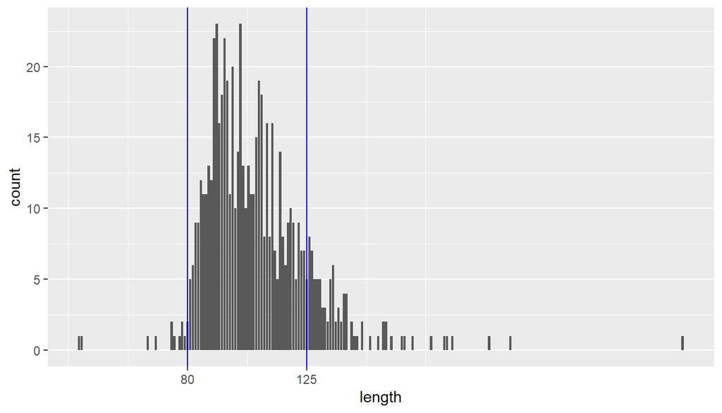

```r
#The length of the movies around 80-125 minutes are most common
ggplot(aes(x = length), data = movies)+geom_bar()+scale_x_continuous(breaks = c(80, 125))+geom_vline(xintercept = c(80, 125), color = "blue")
```

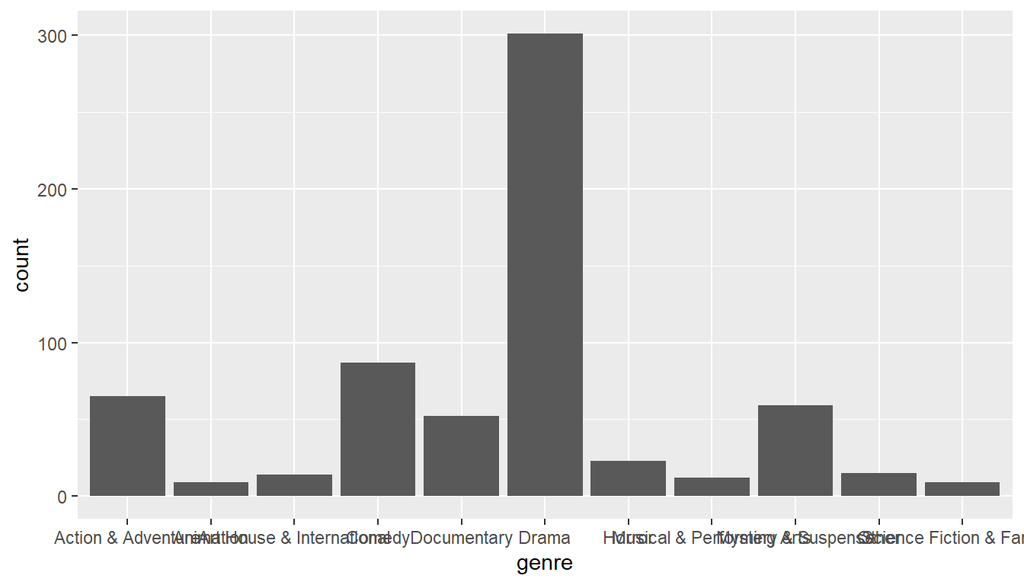

```r
#Drama movies are the most watched in the genre class
ggplot(data = movies, aes(x = genre))+geom_bar()
```

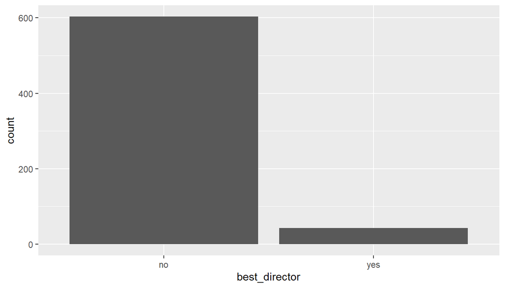

```r
ggplot(data = movies, aes(x = best_director))+geom_bar()
```

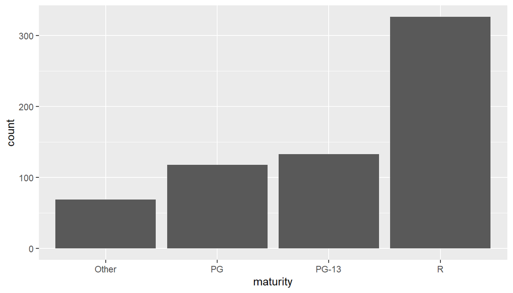

```r
#R rated movies are the most watched content
ggplot(data = movies, aes(x = maturity))+geom_bar()
```

```r
sort(summary(movies$genre))
```

```
##                 Animation Science Fiction & Fantasy Musical & Performing Arts
##                         9                         9                        12
## Art House & International                     Other                    Horror
##                        14                        15                        23
##               Documentary        Mystery & Suspense        Action & Adventure
##                        52                        59                        65
##                    Comedy                     Drama
##                        87                       301
```

As can also be seen from this table, “Drama” movies are the most common class of movies in our data set. However it’s not clear how the genre is determined for each movie. We know that each movie on IMDB is classified under multiple genres. So, it can be assumed that this data set uses the first genre mentioned in genre’s list on IMDB.  
Now, let’s inspect the length variable and its potential outliers. We see some movies with length less than 50 minutes and more than 250 minutes. Let’s see which movies are these:

```r
movies %>%
  filter(length<50 | length>250)
```

```
## # A tibble: 3 x 12
##   title type  genre length maturity studio  year month   day rating
##   <chr> <fct> <fct>  <dbl> <fct>    <fct>  <dbl> <dbl> <dbl>  <dbl>
## 1 Afri~ Docu~ Docu~     39 Other    Other   1994     4     8    7.3
## 2 Hote~ Docu~ Docu~    267 Other    Other   1988    11     1    7.8
## 3 Sea ~ Docu~ Docu~     40 Other    Other   2007    10     5    7
## # ... with 2 more variables: best_director <fct>, best_actor <lgl>
```

As we see, these are all documentaries. We won’t expect feature films to be this short or long. We won’t eliminate these outliers as we will use these in the later stages.  
**Bivariate analysis**

[figure not shown]

```r
ggplot(data = movies, aes(x = best_actor, y = rating))+geom_boxplot(fill='lightblue')+labs(x = "Best actor", y = "IMDB Rating", title = "Do best actors improve movie ratings?")
```

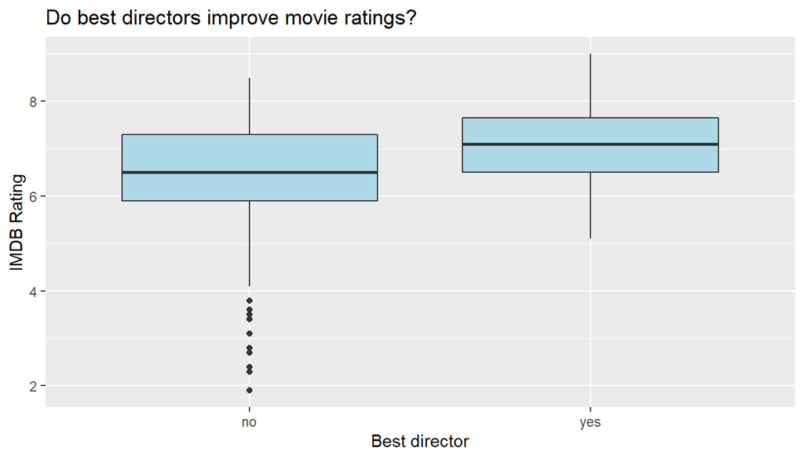

```r
ggplot(data = movies, aes(x = best_director, y = rating))+geom_boxplot(fill='lightblue')+labs(x = "Best director", y = "IMDB Rating", title = "Do best directors improve movie ratings?")
```

As we can see from this boxplot, no movies with ratings below 5 have been directed by an Oscar winning director. And movies directed by Oscar winning directors have significantly higher ratings than movies directed by a non Oscar winning director.  
As we have seen, there is very less number of movies directed by Oscar winning directors, so we have to be careful of sample sizes while using this variable in linear regression section.

[figure not shown]

```r
#Comedy, drama and documentary are the focused genres in our analysis
ggplot(data = movies, aes(x = genre, y = rating))+geom_boxplot(fill='lightblue')+scale_x_discrete(breaks = c("Drama", "Comedy", "Documentary"))+labs(x = "Genre", y = "IMDB rating", title = "Genres preferred by movie-goers")
```

[figure not shown]

```r
ggplot(data = movies, aes(x = maturity, y = rating))+geom_boxplot(fill='lightblue')+labs(x = "Maturity rating", y = "IMDB rating", title = "Movie ratings preferred by movie-goers")
```

The boxplots for PG-13, PG and R movies are comparable to one another. There is however a noticeable jump when comparing them to the Other boxplot. Referring back to our univariate section we saw that 48 out of 69 (70%) of the Other movies were originally Unrated, so we can’t really say too much about the specifics of this class. What we can say is that, due to this difference, maturity is a variable worth considering when building our linear regression model.

[figure not shown]

```r
ggplot(data = movies, aes(x = year, y = rating))+geom_point()+labs(x = "Theater release year", y = "IMDB rating", title = "Movie ratings overs the years")
```

There is no obvious change in movie ratings over the years, and if we were to make charts comparing IMDB ratings to theater release dates by month or day of the month then we would arrive at a similar conclusion.

[figure not shown]

```r
ggplot(data = movies, aes(x = length, y = rating))+geom_point()+geom_vline(xintercept = c(76, 130))+geom_hline(yintercept = 5.5)+geom_hline(yintercept = 5.5, color = "blue")+geom_vline(xintercept = c(76, 130), color = "blue")+scale_y_continuous(breaks = 5.6)+scale_x_continuous(breaks = c(76, 130))+labs(y = "IMDB rating", x = "Length of movie in minutes(runtime)", title = "Preference of movie-goers w.r.t runtime")
```

```r
#Our main variables for prediction are used for making regression model
significant_predictors <- lm(rating ~ type + genre + day + month + best_director + length + maturity + studio + year + best_actor, data = movies)
summary(significant_predictors)
```

```
##
## Call:
## lm(formula = rating ~ type + genre + day + month + best_director +
##     length + maturity + studio + year + best_actor, data = movies)
##
## Residuals:
##     Min      1Q  Median      3Q     Max
## -3.9230 -0.4942  0.0454  0.5735  2.0099
##
## Coefficients:
##                                          Estimate Std. Error t value Pr(>|t|)
## (Intercept)                            15.9554628  7.0723577   2.256 0.024416
## typeFeature Film                       -0.8257802  0.3325214  -2.483 0.013277
## genreAnimation                         -0.0905441  0.3340150  -0.271 0.786421
## genreArt House & International          0.6080849  0.2690221   2.260 0.024145
## genreComedy                            -0.0790758  0.1493900  -0.529 0.596770
## genreDocumentary                        0.8397455  0.3556288   2.361 0.018519
## genreDrama                              0.6525884  0.1269920   5.139 3.71e-07
## genreHorror                            -0.1385741  0.2228453  -0.622 0.534276
## genreMusical & Performing Arts          0.8860223  0.3043275   2.911 0.003727
## genreMystery & Suspense                 0.4185949  0.1672800   2.502 0.012593
## genreOther                              0.7353531  0.2605212   2.823 0.004916
## genreScience Fiction & Fantasy         -0.2560189  0.3204161  -0.799 0.424585
## day                                     0.0006479  0.0041199   0.157 0.875080
## month                                   0.0076758  0.0104463   0.735 0.462749
## best_directoryes                        0.4341608  0.1476050   2.941 0.003390
## length                                  0.0106003  0.0021435   4.945 9.80e-07
## maturityPG                             -0.4406220  0.1612753  -2.732 0.006472
## maturityPG-13                          -0.6326025  0.1649819  -3.834 0.000139
## maturityR                              -0.3095446  0.1492696  -2.074 0.038517
## studioSony Pictures Home Entertainment -0.4982884  0.2318428  -2.149 0.032001
## studioUniversal Pictures                0.3529800  0.2424490   1.456 0.145928
## studioWarner Bros. Pictures             0.1915396  0.2239506   0.855 0.392729
## studioOther                            -0.1821497  0.1577261  -1.155 0.248598
## year                                   -0.0049183  0.0035250  -1.395 0.163428
## best_actorTRUE                         -0.0409256  0.0919890  -0.445 0.656550
##
## (Intercept)                            *
## typeFeature Film                       *
## genreAnimation
```

[output cut: 14 more lines]

```
## maturityPG-13                          ***
## maturityR                              *
## studioSony Pictures Home Entertainment *
## studioUniversal Pictures
## studioWarner Bros. Pictures
## studioOther
## year
## best_actorTRUE
## ---
## Signif. codes:  0 '***' 0.001 '**' 0.01 '*' 0.05 '.' 0.1 ' ' 1
##
## Residual standard error: 0.8957 on 620 degrees of freedom
##   (1 observation deleted due to missingness)
## Multiple R-squared:  0.3351, Adjusted R-squared:  0.3093
## F-statistic: 13.02 on 24 and 620 DF,  p-value: < 2.2e-16
```

```r
signif(summary(significant_predictors)$coefficients[c(2, 7, 13:17), ], 3)
```

```
##                   Estimate Std. Error t value Pr(>|t|)
## typeFeature Film -0.826000    0.33300  -2.480 1.33e-02
## genreDrama        0.653000    0.12700   5.140 3.71e-07
## day               0.000648    0.00412   0.157 8.75e-01
## month             0.007680    0.01040   0.735 4.63e-01
## best_directoryes  0.434000    0.14800   2.940 3.39e-03
## length            0.010600    0.00214   4.950 9.80e-07
## maturityPG       -0.441000    0.16100  -2.730 6.47e-03
```

## Part 4: Modeling

```r
significant_line = lm(rating ~ type + genre + length + maturity + best_director, data=movies)
summary(significant_line)
```

```
##
## Call:
## lm(formula = rating ~ type + genre + length + maturity + best_director,
##     data = movies)
##
## Residuals:
##     Min      1Q  Median      3Q     Max
## -3.8746 -0.4967  0.0530  0.5822  1.9762
##
## Coefficients:
##                                 Estimate Std. Error t value Pr(>|t|)
## (Intercept)                     5.807502   0.416701  13.937  < 2e-16 ***
## typeFeature Film               -0.758137   0.333924  -2.270 0.023522 *
## genreAnimation                 -0.093666   0.334071  -0.280 0.779280
## genreArt House & International  0.551710   0.269189   2.050 0.040826 *
## genreComedy                    -0.109656   0.149656  -0.733 0.464003
## genreDocumentary                0.840147   0.357061   2.353 0.018933 *
## genreDrama                      0.593782   0.126037   4.711 3.03e-06 ***
## genreHorror                    -0.161459   0.223445  -0.723 0.470202
## genreMusical & Performing Arts  0.858788   0.305552   2.811 0.005099 **
## genreMystery & Suspense         0.383889   0.166199   2.310 0.021222 *
## genreOther                      0.713144   0.259811   2.745 0.006227 **
## genreScience Fiction & Fantasy -0.258150   0.321528  -0.803 0.422344
## length                          0.012215   0.002019   6.050 2.50e-09 ***
## maturityPG                     -0.363301   0.159153  -2.283 0.022781 *
## maturityPG-13                  -0.601333   0.162952  -3.690 0.000243 ***
## maturityR                      -0.289696   0.149517  -1.938 0.053127 .
## best_directoryes                0.425841   0.147947   2.878 0.004134 **
## ---
## Signif. codes:  0 '***' 0.001 '**' 0.01 '*' 0.05 '.' 0.1 ' ' 1
##
## Residual standard error: 0.9028 on 628 degrees of freedom
##   (1 observation deleted due to missingness)
## Multiple R-squared:  0.3158, Adjusted R-squared:  0.2984
## F-statistic: 18.12 on 16 and 628 DF,  p-value: < 2.2e-16
```

We see that the adjusted R-squared is 0.2984, which isn’t spectacular but is still sufficient to offer a predictive edge over blind guessing movie quality. There are numerous encouraging details when we inspect the p-values and coefficient signs in this model.  
When searching for the most optimal subset of predictors for a model, it’s tedious to construct all the models and extract the one with the best evaluation metric value due to exponential growth of number of models. As we have chosen 10 predictors, number of models increases to 2^10 = 1024 models.  
To build all 1024 models, we use all.possible.regressions() function.

```r
#The code for this function was found here:
#http://r.789695.n4.nabble.com/Generating-all-possible-models-from-full-model-td2222377.html.

all.possible.regressions <- function(dat, k){
    n <- nrow(dat)
    regressors <- paste("x", 1:k, sep="")
    lst <- rep(list(c(T, F)), k)
    regMat <- expand.grid(lst);
    names(regMat) <- regressors
    formular <- apply(regMat, 1, function(x)
            as.character(paste(c("y ~ 1", regressors[x]), collapse="+")))
    allModelsList <- apply(regMat, 1, function(x)
            as.formula(paste(c("y ~ 1", regressors[x]),collapse=" + ")) )
    allModelsResults <- lapply(allModelsList,
            function(x, data) lm(x, data=data), data=dat)
    n.models <- length(allModelsResults)
    extract <- function(fit) {
        df.sse <- fit$df.residual
        p <- n - df.sse -1
        sigma <- summary(fit)$sigma
        MSE <- sigma^2
        R2 <- summary(fit)$r.squared
        R2.adj <- summary(fit)$adj.r.squared
        sse <- MSE*df.sse
        aic <- n*log(sse) + 2*(p+2)
        bic <- n*log(sse) + log(n)*(p+2)
        out <- data.frame(df.sse=df.sse, p=p, SSE=sse, MSE=MSE,
            R2=R2, R2.adj=R2.adj, AIC=aic, BIC=bic)
        return(out)
    }
    result <- lapply(allModelsResults, extract)
    result <- as.data.frame(matrix(unlist(result), nrow=n.models, byrow=T))
    result <- cbind(formular, result)
rownames(result) <- NULL
colnames(result) <- c("model", "df.sse", "p", "SSE", "MSE", "R2",
"R2.adj", "AIC", "BIC")
    return(result)
}

#This function requires that our target variable be renamed y and our explanatory variables as x1, x2, x3, ...
moviesALL = movies %>%
  select(y=rating, x1=type, x2=genre, x3=length, x4=maturity, x5=studio, x6=year, x7=month, x8=day, x9=best_director, x10=best_actor)

#This is a dataframe that includes all 1024 models and their adjusted R-squared values, among other metrics.
apr = all.possible.regressions(moviesALL,10)
apr[345, ]
```

```
##                        model df.sse  p      SSE       MSE        R2    R2.adj
## 345 y ~ 1+x1+x2+x3+x6+x8+x10    629 16 530.7231 0.8437569 0.2905569 0.2736386
##          AIC      BIC
## 345 4089.159 4169.634
```

We are interested in the model with the highest R^2 adjusted value. Hence, below model shows the model with the highest adjusted R-squared value.

```r
m = which.max(apr$R2.adj)
tibble(model=apr$model[m], R2.adj=round(apr$R2.adj[m],4))
```

```
## # A tibble: 1 x 2
##   model                      R2.adj
##   <chr>                       <dbl>
## 1 y ~ 1+x1+x2+x3+x4+x5+x6+x9  0.312
```

```r
best_line <- lm(rating~type + genre + length + maturity + studio + year + best_director, data=movies)
summary(best_line)
```

```
##
## Call:
## lm(formula = rating ~ type + genre + length + maturity + studio +
##     year + best_director, data = movies)
##
## Residuals:
##     Min      1Q  Median      3Q     Max
## -3.9069 -0.4862  0.0445  0.5686  2.0371
##
## Coefficients:
##                                         Estimate Std. Error t value Pr(>|t|)
## (Intercept)                            15.590552   7.023751   2.220 0.026799
## typeFeature Film                       -0.828039   0.331906  -2.495 0.012861
## genreAnimation                         -0.089205   0.332604  -0.268 0.788632
## genreArt House & International          0.610468   0.267407   2.283 0.022771
## genreComedy                            -0.079053   0.148605  -0.532 0.594937
## genreDocumentary                        0.835745   0.354907   2.355 0.018840
## genreDrama                              0.645215   0.125539   5.140 3.69e-07
## genreHorror                            -0.134802   0.222177  -0.607 0.544249
## genreMusical & Performing Arts          0.891040   0.303690   2.934 0.003469
## genreMystery & Suspense                 0.403081   0.165077   2.442 0.014892
## genreOther                              0.713842   0.258796   2.758 0.005981
## genreScience Fiction & Fantasy         -0.255440   0.319438  -0.800 0.424215
## length                                  0.010765   0.002046   5.261 1.97e-07
## maturityPG                             -0.438323   0.160438  -2.732 0.006473
## maturityPG-13                          -0.637584   0.163930  -3.889 0.000111
## maturityR                              -0.307100   0.148936  -2.062 0.039626
## studioSony Pictures Home Entertainment -0.503539   0.231193  -2.178 0.029780
## studioUniversal Pictures                0.346663   0.241504   1.435 0.151665
## studioWarner Bros. Pictures             0.179364   0.222272   0.807 0.419997
## studioOther                            -0.187246   0.157283  -1.191 0.234301
## year                                   -0.004712   0.003497  -1.347 0.178358
## best_directoryes                        0.433881   0.147144   2.949 0.003311
##
## (Intercept)                            *
## typeFeature Film                       *
## genreAnimation
## genreArt House & International         *
## genreComedy
## genreDocumentary                       *
```

[output cut: 8 more lines]

```
## maturityPG-13                          ***
## maturityR                              *
## studioSony Pictures Home Entertainment *
## studioUniversal Pictures
## studioWarner Bros. Pictures
## studioOther
## year
## best_directoryes                       **
## ---
## Signif. codes:  0 '***' 0.001 '**' 0.01 '*' 0.05 '.' 0.1 ' ' 1
##
## Residual standard error: 0.8941 on 623 degrees of freedom
##   (1 observation deleted due to missingness)
## Multiple R-squared:  0.3342, Adjusted R-squared:  0.3118
## F-statistic: 14.89 on 21 and 623 DF,  p-value: < 2.2e-16
```

## Part 5: Prediction

For predictions, we take 4 movies :  
1. Mission Impossible - Fallout  
2. Birdman  
3. Despicable Me 3  
4. Dunkirk  
We then look up the feature values from IMDB website for each of these movies.

```r
#Gathering the data
test_movies <- tibble(
  title = c("Mission Impossible - Fallout", "Birdman", "Despicable Me 3", "Dunkirk "),
  rating = c(8.1, 7.7, 6.3, 7.9),
  type = as.factor(c("Feature Film", "Feature Film", "Feature Film", "Feature Film")),
  genre = as.factor(c("Action & Adventure", "Drama", "Action & Adventure", "Drama")),
  length = c(147, 119, 89, 106),
  maturity = as.factor(c("PG-13", "R", "PG", "PG-13")),
  studio = as.factor(c("Paramount Pictures", "Other",  "Universal Pictures", "Universal Pictures")),
  year = c(2018, 2014, 2017, 2017),
  best_director = as.factor(c("yes", "yes", "no", "yes"))
)

test_predictions <- predict(best_line, newdata = test_movies, interval = "predict") %>%
  round(1) %>%
  as.data.frame()

tibble(
  title = c("Mission Impossible - Fallout", "Birdman", "Despicable Me 3", "Dunkirk"),
  ratingIMDB = c(8.1, 7.7, 6.3, 7.9),
  ratingPredicted = test_predictions$fit,
  ratingDifference = ratingIMDB-ratingPredicted)
```

```
## # A tibble: 4 x 4
##   title                        ratingIMDB ratingPredicted ratingDifference
##   <chr>                             <dbl>           <dbl>            <dbl>
## 1 Mission Impossible - Fallout        8.1             6.6              1.5
## 2 Birdman                             7.7             7.1              0.6
## 3 Despicable Me 3                     6.3             6.1              0.2
## 4 Dunkirk                             7.9             7.2              0.7
```

It’s impossible to tell from just 4 test points how well our model has done. On the one hand, an error of 0.2 points out of 10 (2%) sounds reasonable, but on the other hand, an error of 1.5 out of 10 (15%) does not.  
To obtain a more trustworthy estimate for our out-of-sample adjusted R-squared we would need to acquire a bigger data set.